# Week_6_Homework

Kassandra Jensen

2024-10-04

# Directions

Take any of the data sheets you have already worked with in class and create at least one table and one figure in an Rmarkdown file. Create the most beautiful RMarkdown output you can in either an html, github doc, or pdf format. YOU MUST KNIT THE FILE Make sure you have headings with clear explanations of what you are doing. Practice using markdown formatting with bold, italics, and lists (use each of these at least once). Make sure your outputs and scripts are saved in the appropriate folders. Keep proper coding etiquette (figures need to be pub quality as usual and you need to comment your code).

# Description

#### This document will be used to showcase environmental data collected from Mo’orea.

#### The following will include:

- A glimpse of the raw data
- A table showcasing nulmerical values of selected variables
- A graph representing the values of selected variables for further comparison

# Libraries used

```r
library(tidyverse)
library(here)
library(kableExtra)
```

# Data

#### View Data

###### This data is from *Week 5* of class.

```r
site_data <- read_csv(here("Week05", "Data", "site.characteristics.data.csv"))
view(site_data)
glimpse(site_data)
```

```
## Rows: 78
## Columns: 5
## $ name               <chr> "Anemone Heaven", "Hilton High", "Public Beach", "M…
## $ site.letter        <chr> "F", "C", "B", "E", "D", "A", "F", "C", "B", "E", "…
## $ site.block         <dbl> 1, 2, 3, 1, 2, 3, 1, 2, 3, 1, 2, 3, 1, 2, 3, 1, 2, …
## $ parameter.measured <chr> "light", "light", "light", "light", "light", "light…
## $ values             <dbl> 1674.241, 1193.230, 2647.890, 1533.245, 2114.013, 2…
```

# Average Values

#### Average values of

1. **Algal Cover**
2. **CCA Cover** (crustose coralline algae cover)
3. **Coral Cover**
4. **Substrate Cover**

```r
site_data_wide <- site_data %>%                                     ## Call data
  group_by(name, parameter.measured) %>%                            ## Select certain columns
  summarise(mean_values = mean(values, na.rm = TRUE)) %>%           ## Get mean values
  pivot_wider(names_from = parameter.measured,                      ## Pivot wide to make table
              values_from = mean_values) %>%                        ## Get information needed from these columns
 select(algal.cover, CCA.cover, coral.cover, substrate.cover)       ## Select specific variables to look at

## Make table
site_data_wide %>%                                                  ## Call data
  kbl() %>%                                                         ## Use kbl function to make table
  kable_classic() %>%                                               ## Use classic theme
  kable_styling(full_width = FALSE)                                 ## Table will only take up as much space as necessary, won't be stretched
```

| name | algal.cover | CCA.cover | coral.cover | substrate.cover |
| --- | --- | --- | --- | --- |
| Anemone Heaven | 37.150 | 6.10 | 16.95 | 33.500 |
| Creepy Tree | 14.500 | 15.25 | 21.75 | 45.500 |
| Hilton High | 32.625 | 10.25 | 35.75 | 14.875 |
| Manava | 22.375 | 4.00 | 20.05 | 50.075 |
| Public Beach | 20.000 | 7.50 | 33.75 | 22.750 |
| Sargassum Heaven | 14.500 | 1.25 | 28.00 | 56.000 |

# Visual plot

```r
## Change dimensions for document

site_data_long <- site_data_wide %>%                                ## Call and rename data
  pivot_longer(cols = algal.cover:substrate.cover,                  ## Revert to long form ## Only use certain variables
               names_to = "Variable",                               ## Rename column
               values_to = "Mean_Value")                            ## Rename column
view(site_data_long)
```

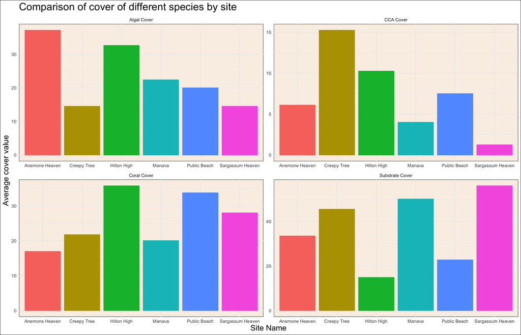

```r
## Make plot
ggplot(site_data_long, aes(x = name,                                ## Choose X and Y variables
                           y = Mean_Value,
                           color = name,                            ## Color different sites
                           fill = name)) +                          ## Fill in with same colors
  geom_col() +                                                      ## Use geom_col to visualize cover
  facet_wrap(~ Variable,                                            ## Facet by each variable,
             scales = "free",                                       ## Each plot has different scale that will better showcase results
             labeller = as_labeller(c(                              ## Change individual plot labels
               "algal.cover" = "Algal Cover",
               "CCA.cover" = "CCA Cover",
               "coral.cover" = "Coral Cover",
               "substrate.cover" = "Substrate Cover"
             ))) +
  labs(x = "Site Name",                                             ## Change titles
       y = "Average cover value",
       title = "Comparison of cover of different species by site") +
  scale_color_discrete(guide = "none") +                            ## Remove color legend
  scale_fill_discrete(guide = "none") +                             ## Remove fill legend
  theme_minimal() +                                                 ## Minimal theme
  theme(                                                            ## Change sizes and colors
    axis.title = element_text(size = 15),
    panel.background = element_rect(fill = "linen"),
    plot.background = element_rect(fill = "white"),
    plot.title = element_text(size = 20),
    plot.subtitle = element_text(size = 10)
  )
```